# Answer for LAQ1

Aneufinder( inputfolder = “C:/Users/dell/Downloads/AneuFinder/Snu119_F12/”, outputfolder = “C:/Users/dell/Downloads/AneuFinder/Snu119_F12/Aneufinder/”, assembly = “hg38”, numCPU = 2, binsizes = c(1e6), blacklist = “C:/Users/dell/Downloads/AneuFinder/hg38-blacklist.v2.bed”, correction.method = “GC”, GC.BSgenome = BSgenome.Hsapiens.UCSC.hg38, refine.breakpoints = FALSE, method = “edivisive”, chromosomes = c(“1”, “2”, “3”, “4”, “5”, “6”, “7”, “8”, “9”, “10”, “11”, “12”, “13”, “14”, “15”, “16”, “17”, “18”, “19”, “20”, “21”, “22”, “X”) )

[output not shown]

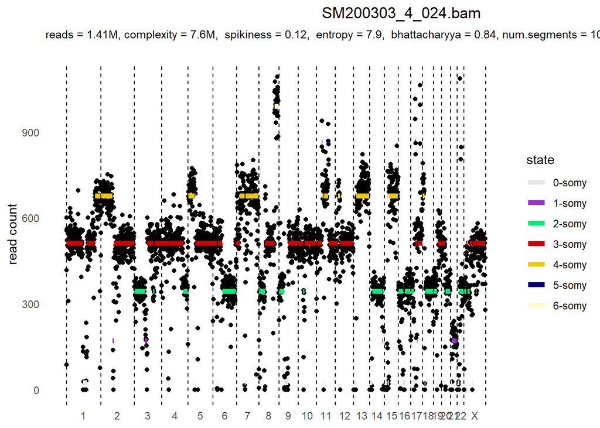

```r
#function to open CNV bedfiles
# Read file into a table, ensuring correct tab separation and filling missing values
Snu119_F12_data <- read.table(
  "C:/Users/dell/Downloads/AneuFinder/Snu119_F12/Aneufinder/BROWSERFILES/method-edivisive/binsize_1e+06_stepsize_1e+06_CNV.bed.gz",
  header = FALSE,
  sep = "\t",
  fill = TRUE,
  na.strings = ""
)

# Read the BED file line by line
lines_F12 <- readLines("C:/Users/dell/Downloads/AneuFinder/Snu119_F12/Aneufinder/BROWSERFILES/method-edivisive/binsize_1e+06_stepsize_1e+06_CNV.bed.gz")

# Initialize empty list for CNA records
F12_records <- list()

# Define regex to extract cell_id from BAM file names
cell_id_pattern_F12 <- "SM[0-9_]+(?=\\.bam)"

# Initialize cell_id variable
cell_id_F12 <- NA

# Process each line
for (line in lines_F12) {
    if (startsWith(line, "track")) {
        # Extract cell_id using regex
        match <- regexpr(cell_id_pattern_F12, line, perl = TRUE)
        if (match > 0) {
            cell_id_F12 <- regmatches(line, match)
        }
    }
    # Check if the line contains CNA segment data
    else if (startsWith(line, "chr")) {
        # Split the line into values
        line_values_F12 <- unlist(strsplit(line, "\t"))

        # Ensure minimum required columns exist
        if (length(line_values_F12) >= 5) {
            chrom_F12 <- line_values_F12[1]
            start <- as.integer(line_values_F12[2])
            end <- as.integer(line_values_F12[3])
            copy_number_F12 <- as.integer(gsub("-somy", "", line_values_F12[4]))

            # Handle color conversion (if column 9 exists)
            if (length(line_values_F12) >= 9) {
                rgb_values_F12 <- as.integer(unlist(strsplit(line_values_F12[9], ",")))
                if (length(rgb_values_F12) == 3) {
                    color_F12 <- sprintf("#%02x%02x%02x", rgb_values_F12[1], rgb_values_F12[2], rgb_values_F12[3])
                } else {
                    color_F12 <- NA
                }
            } else {
                color_F12 <- NA
            }

            # Append CNA segment to the list
            F12_records <- append(F12_records, list(data.frame(
                cell_id = cell_id_F12,
                chrom = chrom_F12,
                start = start,
                end = end,
                copy_number = copy_number_F12,
                color = color_F12,
                stringsAsFactors = FALSE
            )))
        }
    }
}

# Combine the list into a final dataframe
F12_segments_df <- do.call(rbind, F12_records)

# Return the dataframe
F12_segments_df
```

```
##             cell_id chrom     start       end copy_number   color
## 1    SM200303_4_072  chr1         0 120000000           3 #cd0000
## 2    SM200303_4_072  chr1 120000000 145000000           0 #e5e5e5
## 3    SM200303_4_072  chr1 145000000 150000000           1 #9a32cd
## 4    SM200303_4_072  chr1 150000000 207000000           3 #cd0000
## 5    SM200303_4_072  chr1 207000000 248000000           4 #eec900
## 6    SM200303_4_072  chr2         0  86000000           4 #eec900
## 7    SM200303_4_072  chr2  86000000  94000000           1 #9a32cd
## 8    SM200303_4_072  chr2  94000000 242000000           3 #cd0000
## 9    SM200303_4_072  chr3         0  79000000           2 #00ee76
## 10   SM200303_4_072  chr3  79000000  94000000           1 #9a32cd
## 11   SM200303_4_072  chr3  94000000 137000000           3 #cd0000
## 12   SM200303_4_072  chr3 137000000 145000000           2 #00ee76
## 13   SM200303_4_072  chr3 145000000 198000000           3 #cd0000
## 14   SM200303_4_072  chr4         0 157000000           3 #cd0000
```

[output cut: 1142 more lines]

```r
#load up r utilities so we can unzip the bed file from AneuFinder
library(R.utils)
Snu119_F12 <- "C:/Users/dell/Downloads/AneuFinder/Snu119_F12/Aneufinder/BROWSERFILES/method-edivisive/binsize_1e+06_stepsize_1e+06_CNV.bed.gz"
#gunzip(Snu119_F12, remove = FALSE) # Set remove = TRUE to delete the .gz file after unzipping

# Load the gzipped BED file
filepath_Snu119_F12 <- "C:/Users/dell/Downloads/AneuFinder/Snu119_F12/Aneufinder/BROWSERFILES/method-edivisive/binsize_1e+06_stepsize_1e+06_CNV.bed"
Snu119_F12_segments <- read.table(filepath_Snu119_F12, header = FALSE,
                                    sep = "",
                                    fill = TRUE, )

# View first few rows
head(Snu119_F12_segments)
```

```
##      V1        V2        V3     V4                  V5               V6
## 1 track name="CNV     state    for SM200303_4_072.bam" description="CNV
## 2  chr1         0 120000000 3-somy                   0                .
## 3  chr1 120000000 145000000 0-somy                   0                .
## 4  chr1 145000000 150000000 1-somy                   0                .
## 5  chr1 150000000 207000000 3-somy                   0                .
## 6  chr1 207000000 248000000 4-somy                   0                .
##          V7        V8                  V9          V10        V11         V12
## 1     state       for SM200303_4_072.bam" visibility=1 itemRgb=On priority=54
## 2         0 120000000             205,0,0
## 3 120000000 145000000         229,229,229
## 4 145000000 150000000          154,50,205
## 5 150000000 207000000             205,0,0
## 6 207000000 248000000           238,201,0
```

```r
# Add a new column to track breakpoints
F12_segments_df <- F12_segments_df %>%
  group_by(chrom) %>%
  arrange(start) %>%  # Ensure data is ordered by genomic position
  mutate(breakpoint = c(0, diff(copy_number) != 0))  # 1 if copy number changes, 0 otherwise
# Count breakpoints per chromosome
breakpoints_per_chromosome_4 <- F12_segments_df %>%
  group_by(chrom) %>%
  summarise(total_breakpoints = sum(breakpoint))

# results
print(breakpoints_per_chromosome_4)
```

```
## # A tibble: 23 × 2
##    chrom total_breakpoints
##    <chr>             <dbl>
##  1 chr1                 13
##  2 chr10                10
##  3 chr11                20
##  4 chr12                 6
##  5 chr13                12
##  6 chr14                 4
##  7 chr15                10
##  8 chr16                 8
##  9 chr17                19
## 10 chr18                 7
## # ℹ 13 more rows
```